# acb

```python
import json as js
import pandas as pd
import math as m
import matplotlib.pyplot as plt
import numpy as np
import matplotlib as mpl
```

**Se va a analizar el json obtenido de la jornada virtual de la ACB del partido que enfrentó al Estudiantes vs el Barsa**

```python
with open('data1.json', 'r',encoding="utf8") as file:
    data = file.read()

campos=js.loads(data)
```

**La primera acción es visualizar cómo transcurrió el partido observando el desarrollo del marcador:**

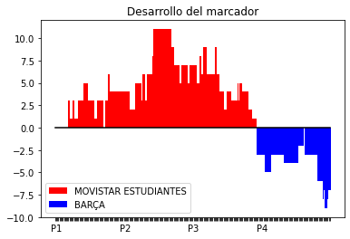

```python
leaddata=[]   #lista con la información del leaddata durante el partido

leaddata=[campos['leaddata'][0],campos['leaddata'][1]]

linea_cero=[] #Para mostrar la linea en 0
ejeX1=[] # 1 color para cuando la diferencia sea mayor que cero
ejeX2=[] # Otro color para cuando la diferencia sea mayor que cero
lead1=[]
lead2=[]
mapeado=range(len(leaddata[0]))

for i in range(len(leaddata[1])):
    linea_cero.append(0)
    if leaddata[1][i]>0:  #Equipo local ganado
        ejeX1.append(i)
        lead1.append(leaddata[1][i])
    else:                #Equipo visitante ganado
        ejeX2.append(i)
        lead2.append(leaddata[1][i])

plt.plot(linea_cero,color='black') # Linea de diferencia 0 puntos
plt.bar(ejeX1,lead1,color='red',label=campos['tm']['1']['name'],width=1) #Equipo local ganado
plt.bar(ejeX2,lead2,color='blue',label=campos['tm']['2']['name'],width=1) #Equipo visitante ganado
plt.xticks(mapeado,leaddata[0])
plt.legend(loc='lower left')
plt.title('Desarrollo del marcador',)
plt.show()
```

Se contemplan dos fases muy diferenciadas en el partido:

```
- Primer Tiempo: La ventaja del Estudiantes en el marcador no hace más que crecer, incluso llegando a obtener una máxima   ventaja de 11 puntos.

- Segundo Tiempo:El Barsa empieza a remontar hasta tomar la delantera antes del último cuarto, donde la ventaja no hace más que aumentar hasta el resultado final.
```

**Pero qué cambió en el juego del Estudiantes entre ambas partes? Fue más un problema ofensivo o defensivo?**

Para obtener más información se sacan los parciales de cada cuarto:

```python
cuartos=['1 Q', '2 Q', '3 Q', '4 Q','FINAL']
loccuartos=[campos['tm']['1']['p1_score'],campos['tm']['1']['p2_score'],campos['tm']['1']['p3_score'],campos['tm']['1']['p4_score'],campos['tm']['1']['full_score']]
viscuartos=[campos['tm']['2']['p1_score'],campos['tm']['2']['p2_score'],campos['tm']['2']['p3_score'],campos['tm']['2']['p4_score'],campos['tm']['2']['full_score']]


P_Dfcuartos = pd.DataFrame(data = list(zip(cuartos,loccuartos,viscuartos)),
                    columns = ["Periodo",campos['tm']['1']['name'],campos['tm']['2']['name']])


P_Dfcuartos
```

|  | Periodo | MOVISTAR ESTUDIANTES | BARÇA |
| --- | --- | --- | --- |
| 0 | 1 Q | 17 | 13 |
| 1 | 2 Q | 18 | 15 |
| 2 | 3 Q | 17 | 27 |
| 3 | 4 Q | 15 | 19 |
| 4 | FINAL | 67 | 74 |

Diferenciando ataque y defensa:

```
- Ataque: Anotaciones parecidas entre cuartos, algo más bajas en la 2º mitad.

- Defensa: Casi el doble de puntos recibidos en la segunda mitad.
```

**¿A que se debe esta diferencia en los puntos recibidos en la 2º mitad?**

Se van a analizar las jugadas defensivas y ofensivas en ambas partes para buscar una explicación en los datos a este resultado:

```python
acciones=[]   #lista con todas las acciones del partido

for accion in range(len(campos['pbp'])):
    acciones.append(campos['pbp'][accion])

locparte1=[] # acciones ofensivas del Estudiantes de la primera parte
locparte2=[] # acciones ofensivas del Estudiantes de la segunda parte
visparte1=[] # acciones ofensivas del Barca de la primera parte
visparte2=[] # acciones ofensivas del Barca de la segunda parte

for accion in range(len(acciones)):
# Seleccionamos las acciones de tiro(tiro libre, tiro de 2p y triple) y las pérdidas y asistencias para analizar el ataque del Estudiantes
    if (acciones[accion]['actionType']=='freethrow' or acciones[accion]['actionType']=='3pt' or acciones[accion]['actionType']=='2pt' or acciones[accion]['actionType']=='turnover' or acciones[accion]['actionType']=='assist') and acciones[accion]['tno']==1:
        if acciones[accion]['period']==1 or acciones[accion]['period']==2:
            locparte1.append(acciones[accion])
        elif acciones[accion]['period']==3 or acciones[accion]['period']==4:
            locparte2.append(acciones[accion])
# Seleccionamos las accionesofensivas del Barca para analizar la defensa del Estudiantes
    if (acciones[accion]['actionType']=='freethrow' or acciones[accion]['actionType']=='3pt' or acciones[accion]['actionType']=='2pt' or acciones[accion]['actionType']=='turnover' or acciones[accion]['actionType']=='assist') and acciones[accion]['tno']==2:
        if acciones[accion]['period']==1 or acciones[accion]['period']==2:
            visparte1.append(acciones[accion])
        elif acciones[accion]['period']==3 or acciones[accion]['period']==4:
            visparte2.append(acciones[accion])
```

Una vez clasificadas las acciones ofensivas más significativas del Estudiantes y Barca en las 2 partes se pasa a segmentar estas acciones en los siguientes campos para cada jugador:

```
- Posesiones ejecutadas (Cada tl se toma cómo 0,5 posesiones y redondeado a la baja en caso de 2+1 o tres tiros).
- Puntos anotados.
- Eficiencia del jugador: Puntos anotado por cada posesión ejecutada.
- Tiros libres intentados.
- Tiros libres anotados.
- % de tiros libres.
- Tiros de 2 intentados.
- Tiros de 2 anotados.
- % de tiros de 2.
- Tiros de 3 intentados.
- Tiros de 3 anotados.
- % de tiros de 3.
- Asistencias.
- Pérdidas.
```

**Se comienza analizando la defensa del Estudiantes,** ya que parece ser el principal problema en la segunda mitad. Para ello se estudian las acciones del Barca. Posteriormente también se analizará la ofensiva del Estudiantes.

Para las acciones ofensivas del Barca en primera parte:

```python
visplayerlist1P=[]
vistlintentados1P=[]
vistlanotados1P=[]
vist2intentados1P=[]
vist2anotados1P=[]
vist3intentados1P=[]
vist3anotados1P=[]
visassist1P=[]
visperdidas1P=[]

for accion in range(len(visparte1)):
    if visparte1[accion]['player'] in visplayerlist1P:
        index=visplayerlist1P.index(visparte1[accion]['player'])
        if visparte1[accion]['actionType']=='freethrow':
            vistlintentados1P[index]=vistlintentados1P[index]+1
            if visparte1[accion]['success']==1:
                vistlanotados1P[index]=vistlanotados1P[index]+1
        if visparte1[accion]['actionType']=='2pt':
            vist2intentados1P[index]=vist2intentados1P[index]+1
            if visparte1[accion]['success']==1:
                vist2anotados1P[index]=vist2anotados1P[index]+1
        if visparte1[accion]['actionType']=='3pt':
            vist3intentados1P[index]=vist3intentados1P[index]+1
            if visparte1[accion]['success']==1:
                vist3anotados1P[index]=vist3anotados1P[index]+1
        if visparte1[accion]['actionType']=='assist':
            visassist1P[index]=visassist1P[index]+1
        if visparte1[accion]['actionType']=='turnover':
            visperdidas1P[index]=visperdidas1P[index]+1
    else:
        visplayerlist1P.append(visparte1[accion]['player'])
        if visparte1[accion]['actionType']=='freethrow':
            vistlintentados1P.append(1)
            if visparte1[accion]['success']==1:
                vistlanotados1P.append(1)
            else:
                vistlanotados1P.append(0)
        else:
            vistlintentados1P.append(0)
            vistlanotados1P.append(0)
        if visparte1[accion]['actionType']=='2pt':
            vist2intentados1P.append(1)
            if visparte1[accion]['success']==1:
                vist2anotados1P.append(1)
            else:
                vist2anotados1P.append(0)
        else:
            vist2intentados1P.append(0)
            vist2anotados1P.append(0)
        if visparte1[accion]['actionType']=='3pt':
            vist3intentados1P.append(1)
            if visparte1[accion]['success']==1:
                vist3anotados1P.append(1)
            else:
                vist3anotados1P.append(0)
        else:
            vist3intentados1P.append(0)
            vist3anotados1P.append(0)
        if visparte1[accion]['actionType']=='assist':
            visassist1P.append(1)
        else:
            visassist1P.append(0)
        if visparte1[accion]['actionType']=='turnover':
            visperdidas1P.append(1)
        else:
            visperdidas1P.append(0)


visposesiones1P=[]
visptanotados1P=[]
viseficiencia1P=[]
vistlporcentaje1P=[]
vist2porcentaje1P=[]
vist3porcentaje1P=[]
for player in range(len(visplayerlist1P)):
    visposesiones1P.append(m.floor(vistlintentados1P[player]*0.5)+vist2intentados1P[player]+vist3intentados1P[player]+visperdidas1P[player])
    visptanotados1P.append((vistlanotados1P[player]+2*vist2anotados1P[player]+3*vist3anotados1P[player]))
    try:
        viseficiencia1P.append(visptanotados1P[player]/visposesiones1P[player])
    except:
        viseficiencia1P.append(0.0)
    try:
        vistlporcentaje1P.append(100*(vistlanotados1P[player]/vistlintentados1P[player]))
    except ZeroDivisionError:
        vistlporcentaje1P.append(0.0)
    try:
        vist2porcentaje1P.append(100*(vist2anotados1P[player]/vist2intentados1P[player]))
    except ZeroDivisionError:
        vist2porcentaje1P.append(0.0)
    try:
        vist3porcentaje1P.append(100*(vist3anotados1P[player]/vist3intentados1P[player]))
    except ZeroDivisionError:
        vist3porcentaje1P.append(0.0)


visP_Df1P = pd.DataFrame(data = list(zip(visplayerlist1P,visposesiones1P,visptanotados1P,viseficiencia1P,vistlanotados1P,vistlintentados1P,vistlporcentaje1P,vist2anotados1P,vist2intentados1P,vist2porcentaje1P,vist3anotados1P,vist3intentados1P,vist3porcentaje1P,visassist1P,visperdidas1P)),
                    columns = ["Name","Posesiones","Puntos anotados","Efieciencia","TL anotados","TL intentados","% TL","2P anotados","2P intentados","% 2P","3P anotados","3P intentados","% 3P","Asistencias","Perdidas"])

visP_Df1P =visP_Df1P.sort_values(by=['Posesiones'],ascending=False)
```

Para la segunda parte:

```python
visplayerlist2P=[]
vistlintentados2P=[]
vistlanotados2P=[]
vist2intentados2P=[]
vist2anotados2P=[]
vist3intentados2P=[]
vist3anotados2P=[]
visassist2P=[]
visperdidas2P=[]

for accion in range(len(visparte2)):
    if visparte2[accion]['player'] in visplayerlist2P:
        index=visplayerlist2P.index(visparte2[accion]['player'])
        if visparte2[accion]['actionType']=='freethrow':
            vistlintentados2P[index]=vistlintentados2P[index]+1
            if visparte2[accion]['success']==1:
                vistlanotados2P[index]=vistlanotados2P[index]+1
        if visparte2[accion]['actionType']=='2pt':
            vist2intentados2P[index]=vist2intentados2P[index]+1
            if visparte2[accion]['success']==1:
                vist2anotados2P[index]=vist2anotados2P[index]+1
        if visparte2[accion]['actionType']=='3pt':
            vist3intentados2P[index]=vist3intentados2P[index]+1
            if visparte2[accion]['success']==1:
                vist3anotados2P[index]=vist3anotados2P[index]+1
        if visparte2[accion]['actionType']=='assist':
            visassist2P[index]=visassist2P[index]+1
        if visparte2[accion]['actionType']=='turnover':
            visperdidas2P[index]=visperdidas2P[index]+1
    else:
        visplayerlist2P.append(visparte2[accion]['player'])
        if visparte2[accion]['actionType']=='freethrow':
            vistlintentados2P.append(1)
            if visparte2[accion]['success']==1:
                vistlanotados2P.append(1)
            else:
                vistlanotados2P.append(0)
        else:
            vistlintentados2P.append(0)
            vistlanotados2P.append(0)
        if visparte2[accion]['actionType']=='2pt':
            vist2intentados2P.append(1)
            if visparte2[accion]['success']==1:
                vist2anotados2P.append(1)
            else:
                vist2anotados2P.append(0)
        else:
            vist2intentados2P.append(0)
            vist2anotados2P.append(0)
        if visparte2[accion]['actionType']=='3pt':
            vist3intentados2P.append(1)
            if visparte2[accion]['success']==1:
                vist3anotados2P.append(1)
            else:
                vist3anotados2P.append(0)
        else:
            vist3intentados2P.append(0)
            vist3anotados2P.append(0)
        if visparte2[accion]['actionType']=='assist':
            visassist2P.append(1)
        else:
            visassist2P.append(0)
        if visparte2[accion]['actionType']=='turnover':
            visperdidas2P.append(1)
        else:
            visperdidas2P.append(0)



visposesiones2P=[]
visptanotados2P=[]
viseficiencia2P=[]
vistlporcentaje2P=[]
vist2porcentaje2P=[]
vist3porcentaje2P=[]

for player in range(len(visplayerlist2P)):
    visposesiones2P.append(m.floor(vistlintentados2P[player]*0.5)+vist2intentados2P[player]+vist3intentados2P[player]+visperdidas2P[player])
    visptanotados2P.append((vistlanotados2P[player]+2*vist2anotados2P[player]+3*vist3anotados2P[player]))
    try:
        viseficiencia2P.append(visptanotados2P[player]/visposesiones2P[player])
    except:
        viseficiencia2P.append(0.0)
    try:
        vistlporcentaje2P.append(100*(vistlanotados2P[player]/vistlintentados2P[player]))
    except ZeroDivisionError:
        vistlporcentaje2P.append(0.0)
    try:
        vist2porcentaje2P.append(100*(vist2anotados2P[player]/vist2intentados2P[player]))
    except ZeroDivisionError:
        vist2porcentaje2P.append(0.0)
    try:
        vist3porcentaje2P.append(100*(vist3anotados2P[player]/vist3intentados2P[player]))
    except ZeroDivisionError:
        vist3porcentaje2P.append(0.0)


visP_Df2P = pd.DataFrame(data = list(zip(visplayerlist2P,visposesiones2P,visptanotados2P,viseficiencia2P,vistlanotados2P,vistlintentados2P,vistlporcentaje2P,vist2anotados2P,vist2intentados2P,vist2porcentaje2P,vist3anotados2P,vist3intentados2P,vist3porcentaje2P,visassist2P,visperdidas2P)),
                    columns = ["Name","Posesiones","Puntos anotados","Efieciencia","TL anotados","TL intentados","% TL","2P anotados","2P intentados","% 2P","3P anotados","3P intentados","% 3P","Asistencias","Perdidas"])

visP_Df2P =visP_Df2P.sort_values(by=['Posesiones'],ascending=False)
```

Comparamos ambas partes:

**1º PARTE:**

```python
visP_Df1P
```

|  | Name | Posesiones | Puntos anotados | Efieciencia | TL anotados | TL intentados | % TL | 2P anotados | 2P intentados | % 2P | 3P anotados | 3P intentados | % 3P | Asistencias | Perdidas |
| --- | --- | --- | --- | --- | --- | --- | --- | --- | --- | --- | --- | --- | --- | --- | --- |
| 0 | A. Hanga | 8 | 7 | 0.875000 | 0 | 0 | 0.0 | 2 | 4 | 50.0 | 1 | 3 | 33.333333 | 1 | 1 |
| 4 | C. Higgins | 7 | 4 | 0.571429 | 2 | 2 | 100.0 | 1 | 2 | 50.0 | 0 | 1 | 0.000000 | 0 | 3 |
| 5 | B. Davies | 6 | 0 | 0.000000 | 0 | 0 | 0.0 | 0 | 2 | 0.0 | 0 | 1 | 0.000000 | 0 | 3 |
| 1 | K. Kuric | 5 | 5 | 1.000000 | 2 | 2 | 100.0 | 0 | 1 | 0.0 | 1 | 3 | 33.333333 | 2 | 0 |
| 7 | M. Delaney | 5 | 2 | 0.400000 | 2 | 2 | 100.0 | 0 | 0 | 0.0 | 0 | 3 | 0.000000 | 1 | 1 |
| 2 | A. Tomic | 3 | 0 | 0.000000 | 0 | 2 | 0.0 | 0 | 1 | 0.0 | 0 | 1 | 0.000000 | 1 | 0 |
| 3 | N. Mirotic | 3 | 6 | 2.000000 | 4 | 4 | 100.0 | 1 | 1 | 100.0 | 0 | 0 | 0.000000 | 0 | 0 |
| 6 | Á. Abrines | 2 | 2 | 1.000000 | 0 | 0 | 0.0 | 1 | 2 | 50.0 | 0 | 0 | 0.000000 | 0 | 0 |
| 8 | V. Claver | 2 | 2 | 1.000000 | 0 | 0 | 0.0 | 1 | 1 | 100.0 | 0 | 0 | 0.000000 | 0 | 1 |

**2º PARTE:**

```python
visP_Df2P
```

|  | Name | Posesiones | Puntos anotados | Efieciencia | TL anotados | TL intentados | % TL | 2P anotados | 2P intentados | % 2P | 3P anotados | 3P intentados | % 3P | Asistencias | Perdidas |
| --- | --- | --- | --- | --- | --- | --- | --- | --- | --- | --- | --- | --- | --- | --- | --- |
| 3 | N. Mirotic | 9 | 11 | 1.222222 | 4 | 4 | 100.000000 | 2 | 5 | 40.000000 | 1 | 2 | 50.000000 | 0 | 0 |
| 2 | C. Higgins | 7 | 8 | 1.142857 | 6 | 6 | 100.000000 | 1 | 3 | 33.333333 | 0 | 0 | 0.000000 | 3 | 1 |
| 5 | P. Oriola | 6 | 4 | 0.666667 | 1 | 4 | 25.000000 | 0 | 0 | 0.000000 | 1 | 3 | 33.333333 | 0 | 1 |
| 4 | A. Hanga | 5 | 7 | 1.400000 | 0 | 0 | 0.000000 | 2 | 2 | 100.000000 | 1 | 1 | 100.000000 | 1 | 2 |
| 0 | K. Kuric | 4 | 6 | 1.500000 | 3 | 4 | 75.000000 | 0 | 0 | 0.000000 | 1 | 1 | 100.000000 | 1 | 1 |
| 1 | Á. Abrines | 4 | 5 | 1.250000 | 2 | 3 | 66.666667 | 0 | 1 | 0.000000 | 1 | 2 | 50.000000 | 0 | 0 |
| 8 | B. Davies | 4 | 4 | 1.000000 | 2 | 3 | 66.666667 | 1 | 3 | 33.333333 | 0 | 0 | 0.000000 | 0 | 0 |
| 6 | P. Ribas | 3 | 1 | 0.333333 | 1 | 2 | 50.000000 | 0 | 0 | 0.000000 | 0 | 1 | 0.000000 | 4 | 1 |
| 7 | A. Tomic | 1 | 0 | 0.000000 | 0 | 0 | 0.000000 | 0 | 0 | 0.000000 | 0 | 0 | 0.000000 | 0 | 1 |
| 9 | V. Claver | 0 | 0 | 0.000000 | 0 | 0 | 0.000000 | 0 | 0 | 0.000000 | 0 | 0 | 0.000000 | 1 | 0 |

Diferencias destacadas:

**1º Parte:**

```
    - Adan Hanga es el jugador que más responsabilidad ha tenido en ataque. Muy bueno por parte de la defensa de Estudiantes ya que en principio es un jugador con un rol más defensivo. La táctica ha sido eficaz ya que este jugador ha tenido eficiencia baja, menor que uno.

    - Se ha reducido la incidencia en el juego del jugador estrella del equipo rival, Nikola Mirotic. Solo ha sido capaz de realizar un único tiro de campo en la primera mitad.

    - Pocas asistencias lo que seguramente sea debido a poca fluidez en el juego provocada por la defensa. La mayoria de los jugadores del Barsa con una eficiencia menor que uno.
```

**2º Parte:**

[output not shown]

Se apoyan estas afirmaciones con los siguientes gráficos radar, dónde se contempla de los jugadores con 5 o más posesiones por parte su anotación, nº de posesiones y eficiencia:

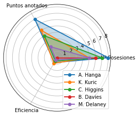

```python
angles = np.linspace(0, 2 * np.pi, 3, endpoint=False)
angles=np.concatenate((angles, [angles[0]]))

for i in range(len(visplayerlist1P)):
    if visposesiones1P[i]>=5:
        visvalues1P = [visposesiones1P[i],visptanotados1P[i],viseficiencia1P[i]]
        visvalues1P=np.concatenate((visvalues1P, [visvalues1P[0]]))
        plt.polar(angles, visvalues1P, 'o-', linewidth=2,label=visplayerlist1P[i])
        plt.fill(angles, visvalues1P, alpha=0.25)

plt.legend(loc='lower right')
labels=['Nº Posesiones', 'Puntos anotados', 'Eficiencia']

# Representación del mapa de calor

plt.thetagrids(angles * 180 / np.pi, labels)
plt.show()
```

**2º Parte:**

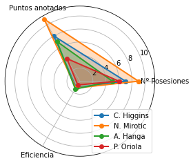

```python
for i in range(len(visplayerlist2P)):
    if visposesiones2P[i]>=5:
        visvalues2P = [visposesiones2P[i],visptanotados2P[i],viseficiencia2P[i]]
        visvalues2P=np.concatenate((visvalues2P, [visvalues2P[0]]))
        plt.polar(angles, visvalues2P, 'o-', linewidth=2,label=visplayerlist2P[i])
        plt.fill(angles, visvalues2P, alpha=0.25)

plt.legend(loc='lower right')

# Representación del mapa de calor

plt.thetagrids(angles * 180 / np.pi, labels)
plt.show()
```

El siguiente paso es analizar las situaciones de tiro entre las dos partes de cara a analizar diferencias en las posiciones de lanzamiento del Barsa. Para ello se necesitan las posiciones de cada tiro (eje X , eje Y).

Para la 1º parte:

```python
visshoots=campos['tm']['2']['shot']
visnum_acciones_tiro1P=[]
for accion in range(len(visparte1)):
    visnum_acciones_tiro1P.append(visparte1[accion]['actionNumber'])

visshoots1P=[]
for shot in range(len(visshoots)):
    if visshoots[shot]['actionNumber'] in visnum_acciones_tiro1P:
        visshoots1P.append(visshoots[shot])
```

Para la 2º parte:

```python
visnum_acciones_tiro2P=[]
for accion in range(len(visparte2)):
    visnum_acciones_tiro2P.append(visparte2[accion]['actionNumber'])

visshoots2P=[]
for shot in range(len(visshoots)):
    if visshoots[shot]['actionNumber'] in visnum_acciones_tiro2P:
        visshoots2P.append(visshoots[shot])
```

Dibujar el cuadro de tiro de ambas partes:

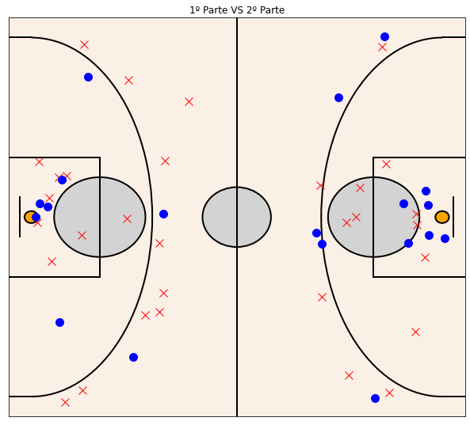

```python
fig = plt.figure(figsize=(8, 7))
ax = fig.add_axes([0, 0, 1, 1],facecolor='linen')
## Dibujar campo de basket lado izquierdo ##
# Short corner 3PT lines
plt.plot([0, 5], [5, 5], linewidth=2, color='black')
plt.plot([0, 5], [95, 95], linewidth=2, color='black')
# 3PT Arc
ax.add_artist(mpl.patches.Arc((5, 50), 53, 90, theta1=270, theta2=90, facecolor='none', edgecolor='black', lw=2))
# Lane and Key
plt.plot([0, 20], [65, 65], linewidth=2, color='black')
plt.plot([0, 20], [35, 35], linewidth=2, color='black')
plt.plot([20, 20], [35, 65], linewidth=2, color='black')
ax.add_artist(mpl.patches.Circle((20, 50), 10, facecolor='lightgrey', edgecolor='black', lw=2))
# Rim
ax.add_artist(mpl.patches.Circle((5, 50), 1.5, facecolor='orange', edgecolor='black', lw=2))
# Backboard
plt.plot([2.5, 2.5], [45, 55], linewidth=2, color='black')
## Dibujar centro del campo ##
plt.plot([50, 50], [0, 100], linewidth=2, color='black')
ax.add_artist(mpl.patches.Circle((50, 50), 7.5, facecolor='lightgrey', edgecolor='black', lw=2))
## Dibujar campo de basket lado derecho ##
# Short corner 3PT lines
plt.plot([95, 100], [5, 5], linewidth=2, color='black')
plt.plot([95, 100], [95, 95], linewidth=2, color='black')
# 3PT Arc
ax.add_artist(mpl.patches.Arc((95, 50), 53, 90, theta1=90, theta2=270, facecolor='none', edgecolor='black', lw=2))
# Lane and Key
plt.plot([80, 100], [65, 65], linewidth=2, color='black')
plt.plot([80, 100], [35, 35], linewidth=2, color='black')
plt.plot([80, 80], [35, 65], linewidth=2, color='black')
ax.add_artist(mpl.patches.Circle((80, 50), 10, facecolor='lightgrey', edgecolor='black', lw=2))
# Rim
ax.add_artist(mpl.patches.Circle((95, 50), 1.5, facecolor='orange', edgecolor='black', lw=2))
# Backboard
plt.plot([97.5, 97.5], [45, 55], linewidth=2, color='black')
# Remove ticks
ax.set_xticks([])
ax.set_yticks([])
# Set pltis limits
ax.set_xlim(0, 100)
ax.set_ylim(0, 100)


for shot in range(len(visshoots1P)):
    if visshoots1P[shot]['r']==1:
        plt.plot(100-visshoots1P[shot]['x'],visshoots1P[shot]['y'],marker="o",markersize=10,color='blue')
    else:
         plt.plot(100-visshoots1P[shot]['x'],visshoots1P[shot]['y'],marker="x",markersize=10,color='red')

for shot in range(len(visshoots2P)):
    if visshoots2P[shot]['r']==1:
        plt.plot(100-visshoots2P[shot]['x'],visshoots2P[shot]['y'],marker="o",markersize=10,color='blue')
    else:
         plt.plot(100-visshoots2P[shot]['x'],visshoots2P[shot]['y'],marker="x",markersize=10,color='red')

plt.title('1º Parte VS 2º Parte')
plt.show()
```

Comparando las gráficas de tiro en ambas partes:

```
- Mejores % en la segunda parte, especialmente en el triple. Malísimos % de 3 en la primera parte.

- Aún así, en la 2º parte se cierra peor la pintura y el Barsa anota más puntos también cerca del aro.

- Muchos menos triples tirados en esta 2º mitad, debido a que habrán encontrado más espacios para penetrar en la zona.
```

Para terminar el estudio defensivo se clasifican las posesiones de ambas partes para compararlas:

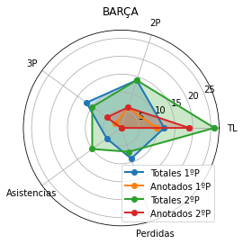

```python
#1º Parte

vistlintentados_equipo1P=0
vistlanotados_equipo1P=0
vist2intentados_equipo1P=0
vist2anotados_equipo1P=0
vist3intentados_equipo1P=0
vist3anotados_equipo1P=0
visassist_equipo1P=0
visperdidas_equipo1P=0
visposesiones_equipo1P=0
visptanotados_equipo1P=0


for player in range(len(visplayerlist1P)):
    vistlintentados_equipo1P=vistlintentados_equipo1P+vistlintentados1P[player]
    vistlanotados_equipo1P=vistlanotados_equipo1P+vistlanotados1P[player]
    vist2intentados_equipo1P=vist2intentados_equipo1P+vist2intentados1P[player]
    vist2anotados_equipo1P=vist2anotados_equipo1P+vist2anotados1P[player]
    vist3intentados_equipo1P=vist3intentados_equipo1P+vist3intentados1P[player]
    vist3anotados_equipo1P=vist3anotados_equipo1P+vist3anotados1P[player]
    visassist_equipo1P=visassist_equipo1P+visassist1P[player]
    visperdidas_equipo1P=visperdidas_equipo1P+visperdidas1P[player]
    visposesiones_equipo1P=visposesiones_equipo1P+visposesiones1P[player]
    visptanotados_equipo1P=visptanotados_equipo1P+visptanotados1P[player]

#2º Parte

vistlintentados_equipo2P=0
vistlanotados_equipo2P=0
vist2intentados_equipo2P=0
vist2anotados_equipo2P=0
vist3intentados_equipo2P=0
vist3anotados_equipo2P=0
visassist_equipo2P=0
visperdidas_equipo2P=0
visposesiones_equipo2P=0
visptanotados_equipo2P=0

for player in range(len(visplayerlist2P)):
    vistlintentados_equipo2P=vistlintentados_equipo2P+vistlintentados2P[player]
    vistlanotados_equipo2P=vistlanotados_equipo2P+vistlanotados2P[player]
    vist2intentados_equipo2P=vist2intentados_equipo2P+vist2intentados2P[player]
    vist2anotados_equipo2P=vist2anotados_equipo2P+vist2anotados2P[player]
    vist3intentados_equipo2P=vist3intentados_equipo2P+vist3intentados2P[player]
    vist3anotados_equipo2P=vist3anotados_equipo2P+vist3anotados2P[player]
    visassist_equipo2P=visassist_equipo2P+visassist2P[player]
    visperdidas_equipo2P=visperdidas_equipo2P+visperdidas2P[player]
    visposesiones_equipo2P=visposesiones_equipo2P+visposesiones2P[player]
    visptanotados_equipo2P=visptanotados_equipo2P+visptanotados2P[player]

angles1 = np.linspace(0, 2 * np.pi, 5, endpoint=False)
angles1=np.concatenate((angles1, [angles1[0]]))

visvalues1P1 = [vistlintentados_equipo1P,vist2intentados_equipo1P,vist3intentados_equipo1P,visassist_equipo1P,visperdidas_equipo1P]
visvalues1P1=np.concatenate((visvalues1P1, [visvalues1P1[0]]))
visvalues2P1 = [vistlanotados_equipo1P,vist2anotados_equipo1P,vist3anotados_equipo1P,0,0]
visvalues2P1=np.concatenate((visvalues2P1, [visvalues2P1[0]]))
visvalues1P2 = [vistlintentados_equipo2P,vist2intentados_equipo2P,vist3intentados_equipo2P,visassist_equipo2P,visperdidas_equipo2P]
visvalues1P2=np.concatenate((visvalues1P2, [visvalues1P2[0]]))
visvalues2P2 = [vistlanotados_equipo2P,vist2anotados_equipo2P,vist3anotados_equipo2P,0,0]
visvalues2P2=np.concatenate((visvalues2P2, [visvalues2P2[0]]))
plt.polar(angles1, visvalues1P1, 'o-', linewidth=2,label='Totales 1ºP')
plt.fill(angles1, visvalues1P1, alpha=0.25)
plt.polar(angles1, visvalues2P1, 'o-', linewidth=2,label='Anotados 1ºP')
plt.fill(angles1, visvalues2P1, alpha=0.25)
plt.polar(angles1, visvalues1P2, 'o-', linewidth=2,label='Totales 2ºP')
plt.fill(angles1, visvalues1P2, alpha=0.25)
plt.polar(angles1, visvalues2P2, 'o-', linewidth=2,label='Anotados 2ºP')
plt.fill(angles1, visvalues2P2, alpha=0.25)

plt.legend(loc='lower right')
plt.title(campos['tm']['2']['name'])
labels=['TL', '2P', '3P','Asistencias','Perdidas']
plt.thetagrids(angles1 * 180 / np.pi, labels)
plt.show()
```

Destaca en la 2º parte el **mayor nº de asistencias** y sobre todo el **nº de tiros libres lanzados**, influenciado seguramente por faltas en los últimos minutos en un intento a la desesperada por remontar.

Por ultimo se comparan las acciones por posesión:

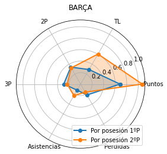

```python
angles2 = np.linspace(0, 2 * np.pi, 6, endpoint=False)
angles2=np.concatenate((angles2, [angles2[0]]))

visvalues3P1 = [visptanotados_equipo1P/visposesiones_equipo1P,vistlintentados_equipo1P/visposesiones_equipo1P,vist2intentados_equipo1P/visposesiones_equipo1P,vist3intentados_equipo1P/visposesiones_equipo1P,visassist_equipo1P/visposesiones_equipo1P,visperdidas_equipo1P/visposesiones_equipo1P]
visvalues3P1=np.concatenate((visvalues3P1, [visvalues3P1[0]]))
visvalues3P2 = [visptanotados_equipo2P/visposesiones_equipo2P,vistlintentados_equipo2P/visposesiones_equipo2P,vist2intentados_equipo2P/visposesiones_equipo2P,vist3intentados_equipo2P/visposesiones_equipo2P,visassist_equipo2P/visposesiones_equipo2P,visperdidas_equipo2P/visposesiones_equipo2P]
visvalues3P2=np.concatenate((visvalues3P2, [visvalues3P2[0]]))
plt.polar(angles2, visvalues3P1, 'o-', linewidth=2,label='Por posesión 1ºP')
plt.fill(angles2, visvalues3P1, alpha=0.25)
plt.polar(angles2, visvalues3P2, 'o-', linewidth=2,label='Por posesión 2ºP')
plt.fill(angles2, visvalues3P2, alpha=0.25)

plt.legend(loc='lower right')
plt.title(campos['tm']['2']['name'])
labels=['Puntos','TL', '2P', '3P','Asistencias','Perdidas']
plt.thetagrids(angles2 * 180 / np.pi, labels)
plt.show()
```

La mayor eficiencia de puntos por posesión de la 2º parte se debe principalmente a un aumento en el nº de asistencias y de tiros libres lanzados.

**CONCLUSIONES DEFENSIVAS**

**1º Parte:**

```
    - Excelente trabajo provocando que Mirotic no entré en juego realizando un único tiro de campo.

    - Se consigue que el jugador que más posesiones ejecute sea Hanga. Muy buena elección ya que es un jugador con un rol más defensivo.

    - Se consigue atascar el ataque del Barsa provocando que no jueguen fluido ya que ni apenas sacan faltas ni consiguen sacar ventajas para realizar asistencias. Se provoca que su ataque se resuma en tiros de 3 defendidos.
```

**2º Parte:**

```
    - Mirotic entra en juego llegando a ejecutar 9 posesiones en esta parte. Se traduce en una mayor eficiencia del equipo.

    - Aumenta el nº de asistencias y sobre todo el nº de tiros libres. Mayor fluidez en el juego de ellos. Consiguen penetrar con facilidad obteniendo más ventajas y jugando más cómodos.

    - A consecuencia del punto anterior se realizan menos triples en la 2º parte pero con mejores %. Se les permite elegir sus tiros buenos.
```

Una vez analizadas las diferencias en el apartato defensivo se va a realizar el **mismo análisis** pero **con las acciones ofensivas del Estudiantes.** En principio por las anotaciones por cuarto vistas al comienzo del documento no parece que se vayan a obtener muchas diferencias, pero el resultado final no tiene por qué indicar una misma forma de juego.

Se comienza clasificando las acciones ofensivas del Estudiantes por jugador:

```python
############ Segmentación jugadas ofensivas 1º parte ######################

locplayerlist1P=[]
loctlintentados1P=[]
loctlanotados1P=[]
loct2intentados1P=[]
loct2anotados1P=[]
loct3intentados1P=[]
loct3anotados1P=[]
locassist1P=[]
locperdidas1P=[]

for accion in range(len(locparte1)):
    if locparte1[accion]['player'] in locplayerlist1P:
        index=locplayerlist1P.index(locparte1[accion]['player'])
        if locparte1[accion]['actionType']=='freethrow':
            loctlintentados1P[index]=loctlintentados1P[index]+1
            if locparte1[accion]['success']==1:
                loctlanotados1P[index]=loctlanotados1P[index]+1
        if locparte1[accion]['actionType']=='2pt':
            loct2intentados1P[index]=loct2intentados1P[index]+1
            if locparte1[accion]['success']==1:
                loct2anotados1P[index]=loct2anotados1P[index]+1
        if locparte1[accion]['actionType']=='3pt':
            loct3intentados1P[index]=loct3intentados1P[index]+1
            if locparte1[accion]['success']==1:
                loct3anotados1P[index]=loct3anotados1P[index]+1
        if locparte1[accion]['actionType']=='assist':
            locassist1P[index]=locassist1P[index]+1
        if locparte1[accion]['actionType']=='turnover':
            locperdidas1P[index]=locperdidas1P[index]+1
    else:
        locplayerlist1P.append(locparte1[accion]['player'])
        if locparte1[accion]['actionType']=='freethrow':
            loctlintentados1P.append(1)
            if locparte1[accion]['success']==1:
                loctlanotados1P.append(1)
            else:
                loctlanotados1P.append(0)
        else:
            loctlintentados1P.append(0)
            loctlanotados1P.append(0)
        if locparte1[accion]['actionType']=='2pt':
            loct2intentados1P.append(1)
            if locparte1[accion]['success']==1:
                loct2anotados1P.append(1)
            else:
                loct2anotados1P.append(0)
        else:
            loct2intentados1P.append(0)
            loct2anotados1P.append(0)
        if locparte1[accion]['actionType']=='3pt':
            loct3intentados1P.append(1)
            if locparte1[accion]['success']==1:
                loct3anotados1P.append(1)
            else:
                loct3anotados1P.append(0)
        else:
            loct3intentados1P.append(0)
            loct3anotados1P.append(0)
        if locparte1[accion]['actionType']=='assist':
            locassist1P.append(1)
        else:
            locassist1P.append(0)
        if locparte1[accion]['actionType']=='turnover':
            locperdidas1P.append(1)
        else:
            locperdidas1P.append(0)


locposesiones1P=[]
locptanotados1P=[]
loceficiencia1P=[]
loctlporcentaje1P=[]
loct2porcentaje1P=[]
loct3porcentaje1P=[]
for player in range(len(locplayerlist1P)):
    locposesiones1P.append(m.floor(loctlintentados1P[player]*0.5)+loct2intentados1P[player]+loct3intentados1P[player]+locperdidas1P[player])
    locptanotados1P.append((loctlanotados1P[player]+2*loct2anotados1P[player]+3*loct3anotados1P[player]))
    try:
        loceficiencia1P.append(locptanotados1P[player]/locposesiones1P[player])
    except:
        loceficiencia1P.append(0.0)
    try:
        loctlporcentaje1P.append(100*(loctlanotados1P[player]/loctlintentados1P[player]))
    except ZeroDivisionError:
        loctlporcentaje1P.append(0.0)
    try:
        loct2porcentaje1P.append(100*(loct2anotados1P[player]/loct2intentados1P[player]))
    except ZeroDivisionError:
        loct2porcentaje1P.append(0.0)
    try:
        loct3porcentaje1P.append(100*(loct3anotados1P[player]/loct3intentados1P[player]))
    except ZeroDivisionError:
        loct3porcentaje1P.append(0.0)


locP_Df1P = pd.DataFrame(data = list(zip(locplayerlist1P,locposesiones1P,locptanotados1P,loceficiencia1P,loctlanotados1P,loctlintentados1P,loctlporcentaje1P,loct2anotados1P,loct2intentados1P,loct2porcentaje1P,loct3anotados1P,loct3intentados1P,loct3porcentaje1P,locassist1P,locperdidas1P)),
                    columns = ["Name","Posesiones","Puntos anotados","Efieciencia","TL anotados","TL intentados","% TL","2P anotados","2P intentados","% 2P","3P anotados","3P intentados","% 3P","Asistencias","Perdidas"])

locP_Df1P =locP_Df1P.sort_values(by=['Posesiones'],ascending=False)


############ Segmentación jugadas  2º parte #####################

locplayerlist2P=[]
loctlintentados2P=[]
loctlanotados2P=[]
loct2intentados2P=[]
loct2anotados2P=[]
loct3intentados2P=[]
loct3anotados2P=[]
locassist2P=[]
locperdidas2P=[]

for accion in range(len(locparte2)):
    if locparte2[accion]['player'] in locplayerlist2P:
        index=locplayerlist2P.index(locparte2[accion]['player'])
        if locparte2[accion]['actionType']=='freethrow':
            loctlintentados2P[index]=loctlintentados2P[index]+1
            if locparte2[accion]['success']==1:
                loctlanotados2P[index]=loctlanotados2P[index]+1
        if locparte2[accion]['actionType']=='2pt':
            loct2intentados2P[index]=loct2intentados2P[index]+1
            if locparte2[accion]['success']==1:
                loct2anotados2P[index]=loct2anotados2P[index]+1
        if locparte2[accion]['actionType']=='3pt':
            loct3intentados2P[index]=loct3intentados2P[index]+1
            if locparte2[accion]['success']==1:
                loct3anotados2P[index]=loct3anotados2P[index]+1
        if locparte2[accion]['actionType']=='assist':
            locassist2P[index]=locassist2P[index]+1
        if locparte2[accion]['actionType']=='turnover':
            locperdidas2P[index]=locperdidas2P[index]+1
    else:
        locplayerlist2P.append(locparte2[accion]['player'])
        if locparte2[accion]['actionType']=='freethrow':
            loctlintentados2P.append(1)
            if locparte2[accion]['success']==1:
                loctlanotados2P.append(1)
            else:
                loctlanotados2P.append(0)
        else:
            loctlintentados2P.append(0)
            loctlanotados2P.append(0)
        if locparte2[accion]['actionType']=='2pt':
            loct2intentados2P.append(1)
            if locparte2[accion]['success']==1:
                loct2anotados2P.append(1)
            else:
                loct2anotados2P.append(0)
        else:
            loct2intentados2P.append(0)
            loct2anotados2P.append(0)
        if locparte2[accion]['actionType']=='3pt':
            loct3intentados2P.append(1)
            if locparte2[accion]['success']==1:
                loct3anotados2P.append(1)
            else:
                loct3anotados2P.append(0)
        else:
            loct3intentados2P.append(0)
            loct3anotados2P.append(0)
        if locparte2[accion]['actionType']=='assist':
            locassist2P.append(1)
        else:
            locassist2P.append(0)
        if locparte2[accion]['actionType']=='turnover':
            locperdidas2P.append(1)
        else:
            locperdidas2P.append(0)


locposesiones2P=[]
locptanotados2P=[]
loceficiencia2P=[]
loctlporcentaje2P=[]
loct2porcentaje2P=[]
loct3porcentaje2P=[]
for player in range(len(locplayerlist2P)):
    locposesiones2P.append(m.floor(loctlintentados2P[player]*0.5)+loct2intentados2P[player]+loct3intentados2P[player]+locperdidas2P[player])
    locptanotados2P.append((loctlanotados2P[player]+2*loct2anotados2P[player]+3*loct3anotados2P[player]))
    try:
        loceficiencia2P.append(locptanotados2P[player]/locposesiones2P[player])
    except:
        loceficiencia2P.append(0.0)
    try:
        loctlporcentaje2P.append(100*(loctlanotados2P[player]/loctlintentados2P[player]))
    except ZeroDivisionError:
        loctlporcentaje2P.append(0.0)
    try:
        loct2porcentaje2P.append(100*(loct2anotados2P[player]/loct2intentados2P[player]))
    except ZeroDivisionError:
        loct2porcentaje2P.append(0.0)
    try:
        loct3porcentaje2P.append(100*(loct3anotados2P[player]/loct3intentados2P[player]))
    except ZeroDivisionError:
        loct3porcentaje2P.append(0.0)


locP_Df2P = pd.DataFrame(data = list(zip(locplayerlist2P,locposesiones2P,locptanotados2P,loceficiencia2P,loctlanotados2P,loctlintentados2P,loctlporcentaje2P,loct2anotados2P,loct2intentados2P,loct2porcentaje2P,loct3anotados2P,loct3intentados2P,loct3porcentaje2P,locassist2P,locperdidas2P)),
                    columns = ["Name","Posesiones","Puntos anotados","Efieciencia","TL anotados","TL intentados","% TL","2P anotados","2P intentados","% 2P","3P anotados","3P intentados","% 3P","Asistencias","Perdidas"])

locP_Df2P =locP_Df2P.sort_values(by=['Posesiones'],ascending=False)
```

```python
locP_Df1P
```

|  | Name | Posesiones | Puntos anotados | Efieciencia | TL anotados | TL intentados | % TL | 2P anotados | 2P intentados | % 2P | 3P anotados | 3P intentados | % 3P | Asistencias | Perdidas |
| --- | --- | --- | --- | --- | --- | --- | --- | --- | --- | --- | --- | --- | --- | --- | --- |
| 3 | A. Avramovic | 9 | 10 | 1.111111 | 0 | 0 | 0.0 | 2 | 4 | 50.0 | 2 | 4 | 50.000000 | 0 | 1 |
| 1 | E. Jackson | 8 | 3 | 0.375000 | 0 | 0 | 0.0 | 0 | 4 | 0.0 | 1 | 3 | 33.333333 | 3 | 1 |
| 8 | P. Scrubb | 6 | 6 | 1.000000 | 0 | 0 | 0.0 | 0 | 0 | 0.0 | 2 | 4 | 50.000000 | 1 | 2 |
| 0 | V. Arteaga | 5 | 8 | 1.600000 | 2 | 2 | 100.0 | 3 | 4 | 75.0 | 0 | 0 | 0.000000 | 0 | 0 |
| 4 | A. Sola | 3 | 0 | 0.000000 | 0 | 0 | 0.0 | 0 | 0 | 0.0 | 0 | 3 | 0.000000 | 1 | 0 |
| 5 | P. Pressey | 3 | 6 | 2.000000 | 0 | 0 | 0.0 | 0 | 0 | 0.0 | 2 | 2 | 100.000000 | 3 | 1 |
| 2 | E. Vicedo | 2 | 0 | 0.000000 | 0 | 0 | 0.0 | 0 | 1 | 0.0 | 0 | 0 | 0.000000 | 0 | 1 |
| 6 | N. Dangubic | 2 | 2 | 1.000000 | 0 | 0 | 0.0 | 1 | 1 | 100.0 | 0 | 1 | 0.000000 | 0 | 0 |
| 7 | B. Mullens | 1 | 0 | 0.000000 | 0 | 0 | 0.0 | 0 | 1 | 0.0 | 0 | 0 | 0.000000 | 1 | 0 |
| 9 | D. Dukan | 1 | 0 | 0.000000 | 0 | 0 | 0.0 | 0 | 0 | 0.0 | 0 | 0 | 0.000000 | 0 | 1 |
| 10 | K. Sow | 1 | 0 | 0.000000 | 0 | 0 | 0.0 | 0 | 0 | 0.0 | 0 | 0 | 0.000000 | 0 | 1 |

```python
locP_Df2P
```

|  | Name | Posesiones | Puntos anotados | Efieciencia | TL anotados | TL intentados | % TL | 2P anotados | 2P intentados | % 2P | 3P anotados | 3P intentados | % 3P | Asistencias | Perdidas |
| --- | --- | --- | --- | --- | --- | --- | --- | --- | --- | --- | --- | --- | --- | --- | --- |
| 0 | A. Avramovic | 9 | 8 | 0.888889 | 2 | 2 | 100.0 | 0 | 3 | 0.0 | 2 | 3 | 66.666667 | 1 | 2 |
| 3 | E. Jackson | 9 | 6 | 0.666667 | 4 | 5 | 80.0 | 1 | 4 | 25.0 | 0 | 3 | 0.000000 | 2 | 0 |
| 4 | P. Scrubb | 8 | 3 | 0.375000 | 3 | 4 | 75.0 | 0 | 3 | 0.0 | 0 | 2 | 0.000000 | 0 | 1 |
| 2 | V. Arteaga | 6 | 6 | 1.000000 | 0 | 0 | 0.0 | 3 | 6 | 50.0 | 0 | 0 | 0.000000 | 0 | 0 |
| 5 | J. Palacios | 6 | 3 | 0.500000 | 0 | 0 | 0.0 | 0 | 2 | 0.0 | 1 | 4 | 25.000000 | 0 | 0 |
| 1 | N. Dangubic | 4 | 3 | 0.750000 | 0 | 0 | 0.0 | 0 | 0 | 0.0 | 1 | 3 | 33.333333 | 1 | 1 |
| 6 | E. Vicedo | 2 | 3 | 1.500000 | 0 | 0 | 0.0 | 0 | 0 | 0.0 | 1 | 2 | 50.000000 | 0 | 0 |
| 7 | A. Sola | 1 | 0 | 0.000000 | 0 | 0 | 0.0 | 0 | 0 | 0.0 | 0 | 0 | 0.000000 | 1 | 1 |

Destacar que en ambas partes los jugadores que más posesiones ejecutan son en el mismo orden:

```
- Abramovic
- Edwin Jackson
- Scrubb
- Arteaga
```

Estos son los jugadores referencia del equipo por lo que a priori, es un buen síntoma que los jugadores que más tiros han realizado sean los mejores jugadores del equipo.

Analizando el caso de **Edwin Jackson**, probablemente el mejor anotador del equipo, se observa que desde el principio no estaba acertado en el tiro y aun así el equipo ha seguido jugando para él. Jackson no ha conseguido dar la vuelta a su mal partido y en la segunda parte ha tirado incluso más tiros que en la primera, encestando unicamente 2 tiros de campo de los 14 realizados en todo el partido. Viendo el mal partido de este, en el segundo tiempo quizá habría sido mejor opción haber utilizado más el juego interior con Victor Arteaga que estaba teniendo mayor eficiencia e incluso la ha mantenido en la segunda parte.

Destaca para mal la **diferencia en asistencias** entre ambas partes. En la segunda parte se realizan 4 menos que en la primera de lo que se traduce que se ha jugado de una forma más individual en esta segunda parte.

En los siguientes gráficos radar se muestran de los jugadores con 5 o más posesiones por parte, su anotación, nº de posesiones y eficiencia:

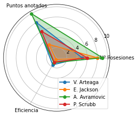

```python
angles = np.linspace(0, 2 * np.pi, 3, endpoint=False)
angles=np.concatenate((angles, [angles[0]]))

for i in range(len(locplayerlist1P)):
    if locposesiones1P[i]>=5:
        locvalues1P = [locposesiones1P[i],locptanotados1P[i],loceficiencia1P[i]]
        locvalues1P=np.concatenate((locvalues1P, [locvalues1P[0]]))
        plt.polar(angles, locvalues1P, 'o-', linewidth=2,label=locplayerlist1P[i])
        plt.fill(angles, locvalues1P, alpha=0.25)

plt.legend(loc='lower right')
labels=['Nº Posesiones', 'Puntos anotados', 'Eficiencia']

# Representación del mapa de calor

plt.thetagrids(angles * 180 / np.pi, labels)
plt.show()
```

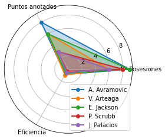

```python
for i in range(len(locplayerlist2P)):
    if locposesiones2P[i]>=5:
        locvalues2P = [locposesiones2P[i],locptanotados2P[i],loceficiencia2P[i]]
        locvalues2P=np.concatenate((locvalues2P, [locvalues2P[0]]))
        plt.polar(angles, locvalues2P, 'o-', linewidth=2,label=locplayerlist2P[i])
        plt.fill(angles, locvalues2P, alpha=0.25)

plt.legend(loc='lower right')

# Representación del mapa de calor

plt.thetagrids(angles * 180 / np.pi, labels)
plt.show()
```

Destacar:

```
- La regularidad de Avramovic con partes practicamente idénticas.

- La baja eficiencia de Jackson siendo el jugador que más interviene en ataque.

- Victor Arteaga es el jugador más eficiente en ambas partes.
```

Análisis de las posiciones de tiro en ambas partes:

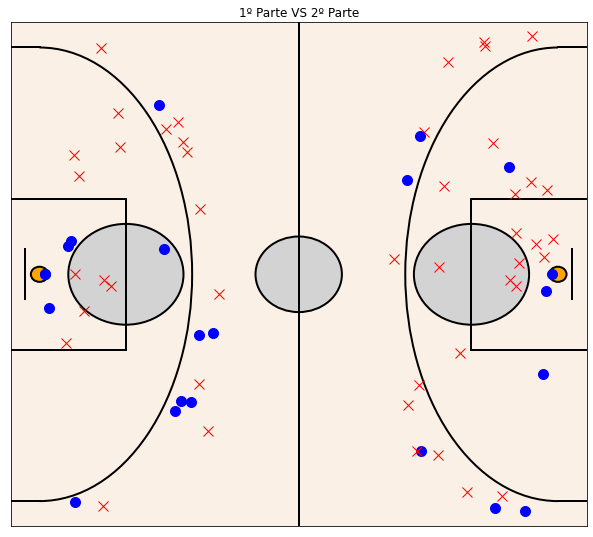

```python
############## Conseguir posiciones de tiro 1º Parte  ###########

locshoots=campos['tm']['1']['shot']
locnum_acciones_tiro1P=[]
for accion in range(len(locparte1)):
    locnum_acciones_tiro1P.append(locparte1[accion]['actionNumber'])

locshoots1P=[]
for shot in range(len(locshoots)):
    if locshoots[shot]['actionNumber'] in locnum_acciones_tiro1P:
        locshoots1P.append(locshoots[shot])

############## Conseguir posiciones de tiro 2º Parte  ###########

locnum_acciones_tiro2P=[]
for accion in range(len(locparte2)):
    locnum_acciones_tiro2P.append(locparte2[accion]['actionNumber'])

locshoots2P=[]
for shot in range(len(locshoots)):
    if locshoots[shot]['actionNumber'] in locnum_acciones_tiro2P:
        locshoots2P.append(locshoots[shot])

######### Dibujar cuadro de tiro de ambas partes ############


fig = plt.figure(figsize=(8, 7))
ax = fig.add_axes([0, 0, 1, 1],facecolor='linen')
## Dibujar campo de basket lado izquierdo ##
# Short corner 3PT lines
plt.plot([0, 5], [5, 5], linewidth=2, color='black')
plt.plot([0, 5], [95, 95], linewidth=2, color='black')
# 3PT Arc
ax.add_artist(mpl.patches.Arc((5, 50), 53, 90, theta1=270, theta2=90, facecolor='none', edgecolor='black', lw=2))
# Lane and Key
plt.plot([0, 20], [65, 65], linewidth=2, color='black')
plt.plot([0, 20], [35, 35], linewidth=2, color='black')
plt.plot([20, 20], [35, 65], linewidth=2, color='black')
ax.add_artist(mpl.patches.Circle((20, 50), 10, facecolor='lightgrey', edgecolor='black', lw=2))
# Rim
ax.add_artist(mpl.patches.Circle((5, 50), 1.5, facecolor='orange', edgecolor='black', lw=2))
# Backboard
plt.plot([2.5, 2.5], [45, 55], linewidth=2, color='black')
## Dibujar centro del campo ##
plt.plot([50, 50], [0, 100], linewidth=2, color='black')
ax.add_artist(mpl.patches.Circle((50, 50), 7.5, facecolor='lightgrey', edgecolor='black', lw=2))
## Dibujar campo de basket lado derecho ##
# Short corner 3PT lines
plt.plot([95, 100], [5, 5], linewidth=2, color='black')
plt.plot([95, 100], [95, 95], linewidth=2, color='black')
# 3PT Arc
ax.add_artist(mpl.patches.Arc((95, 50), 53, 90, theta1=90, theta2=270, facecolor='none', edgecolor='black', lw=2))
# Lane and Key
plt.plot([80, 100], [65, 65], linewidth=2, color='black')
plt.plot([80, 100], [35, 35], linewidth=2, color='black')
plt.plot([80, 80], [35, 65], linewidth=2, color='black')
ax.add_artist(mpl.patches.Circle((80, 50), 10, facecolor='lightgrey', edgecolor='black', lw=2))
# Rim
ax.add_artist(mpl.patches.Circle((95, 50), 1.5, facecolor='orange', edgecolor='black', lw=2))
# Backboard
plt.plot([97.5, 97.5], [45, 55], linewidth=2, color='black')
# Remove ticks
ax.set_xticks([])
ax.set_yticks([])
# Set pltis limits
ax.set_xlim(0, 100)
ax.set_ylim(0, 100)


for shot in range(len(locshoots1P)):
    if locshoots1P[shot]['r']==1:
        plt.plot(locshoots1P[shot]['x'],locshoots1P[shot]['y'],marker="o",markersize=10,color='blue')
    else:
         plt.plot(locshoots1P[shot]['x'],locshoots1P[shot]['y'],marker="x",markersize=10,color='red')

for shot in range(len(locshoots2P)):
    if locshoots2P[shot]['r']==1:
        plt.plot(locshoots2P[shot]['x'],locshoots2P[shot]['y'],marker="o",markersize=10,color='blue')
    else:
         plt.plot(locshoots2P[shot]['x'],locshoots2P[shot]['y'],marker="x",markersize=10,color='red')

plt.title('1º Parte VS 2º Parte')
plt.show()
```

Posiciones de tiro **muy similares** entre ambas partes.

Llama la atención el desacierto de la segunda parte en posiciones cercanas al aro.

Clasificación de las posesiones de ambas partes:

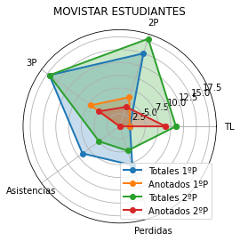

```python
#1º Parte

loctlintentados_equipo1P=0
loctlanotados_equipo1P=0
loct2intentados_equipo1P=0
loct2anotados_equipo1P=0
loct3intentados_equipo1P=0
loct3anotados_equipo1P=0
locassist_equipo1P=0
locperdidas_equipo1P=0
locposesiones_equipo1P=0
locptanotados_equipo1P=0


for player in range(len(locplayerlist1P)):
    loctlintentados_equipo1P=loctlintentados_equipo1P+loctlintentados1P[player]
    loctlanotados_equipo1P=loctlanotados_equipo1P+loctlanotados1P[player]
    loct2intentados_equipo1P=loct2intentados_equipo1P+loct2intentados1P[player]
    loct2anotados_equipo1P=loct2anotados_equipo1P+loct2anotados1P[player]
    loct3intentados_equipo1P=loct3intentados_equipo1P+loct3intentados1P[player]
    loct3anotados_equipo1P=loct3anotados_equipo1P+loct3anotados1P[player]
    locassist_equipo1P=locassist_equipo1P+locassist1P[player]
    locperdidas_equipo1P=locperdidas_equipo1P+locperdidas1P[player]
    locposesiones_equipo1P=locposesiones_equipo1P+locposesiones1P[player]
    locptanotados_equipo1P=locptanotados_equipo1P+locptanotados1P[player]

#2º Parte

loctlintentados_equipo2P=0
loctlanotados_equipo2P=0
loct2intentados_equipo2P=0
loct2anotados_equipo2P=0
loct3intentados_equipo2P=0
loct3anotados_equipo2P=0
locassist_equipo2P=0
locperdidas_equipo2P=0
locposesiones_equipo2P=0
locptanotados_equipo2P=0

for player in range(len(locplayerlist2P)):
    loctlintentados_equipo2P=loctlintentados_equipo2P+loctlintentados2P[player]
    loctlanotados_equipo2P=loctlanotados_equipo2P+loctlanotados2P[player]
    loct2intentados_equipo2P=loct2intentados_equipo2P+loct2intentados2P[player]
    loct2anotados_equipo2P=loct2anotados_equipo2P+loct2anotados2P[player]
    loct3intentados_equipo2P=loct3intentados_equipo2P+loct3intentados2P[player]
    loct3anotados_equipo2P=loct3anotados_equipo2P+loct3anotados2P[player]
    locassist_equipo2P=locassist_equipo2P+locassist2P[player]
    locperdidas_equipo2P=locperdidas_equipo2P+locperdidas2P[player]
    locposesiones_equipo2P=locposesiones_equipo2P+locposesiones2P[player]
    locptanotados_equipo2P=locptanotados_equipo2P+locptanotados2P[player]

angles1 = np.linspace(0, 2 * np.pi, 5, endpoint=False)
angles1=np.concatenate((angles1, [angles1[0]]))

locvalues1P1 = [loctlintentados_equipo1P,loct2intentados_equipo1P,loct3intentados_equipo1P,locassist_equipo1P,locperdidas_equipo1P]
locvalues1P1=np.concatenate((locvalues1P1, [locvalues1P1[0]]))
locvalues2P1 = [loctlanotados_equipo1P,loct2anotados_equipo1P,loct3anotados_equipo1P,0,0]
locvalues2P1=np.concatenate((locvalues2P1, [locvalues2P1[0]]))
locvalues1P2 = [loctlintentados_equipo2P,loct2intentados_equipo2P,loct3intentados_equipo2P,locassist_equipo2P,locperdidas_equipo2P]
locvalues1P2=np.concatenate((locvalues1P2, [locvalues1P2[0]]))
locvalues2P2 = [loctlanotados_equipo2P,loct2anotados_equipo2P,loct3anotados_equipo2P,0,0]
locvalues2P2=np.concatenate((locvalues2P2, [locvalues2P2[0]]))
plt.polar(angles1, locvalues1P1, 'o-', linewidth=2,label='Totales 1ºP')
plt.fill(angles1, locvalues1P1, alpha=0.25)
plt.polar(angles1, locvalues2P1, 'o-', linewidth=2,label='Anotados 1ºP')
plt.fill(angles1, locvalues2P1, alpha=0.25)
plt.polar(angles1, locvalues1P2, 'o-', linewidth=2,label='Totales 2ºP')
plt.fill(angles1, locvalues1P2, alpha=0.25)
plt.polar(angles1, locvalues2P2, 'o-', linewidth=2,label='Anotados 2ºP')
plt.fill(angles1, locvalues2P2, alpha=0.25)

plt.legend(loc='lower right')
plt.title(campos['tm']['1']['name'])
labels=['TL', '2P', '3P','Asistencias','Perdidas']
plt.thetagrids(angles1 * 180 / np.pi, labels)
plt.show()
```

Destacar:

```
- Menos asistencias y peores porcentajes en la 2º parte traducido a peor fluidez de juego que provoca tiros más complicados y por tanto con peor porcentaje.

- Misma cantidad de triples lanzados en ambas partes.

- Llama la atención los pocos tiros libres lanzados en el primer tiempo. Esto probablemente sea debido a un exceso de relajación en la defensa del Barsa en la 1º mitad, que se habrá puesto las pilas en la segunda endureciendo el partido.
```

Por ultimo se comparan las acciones por posesión:

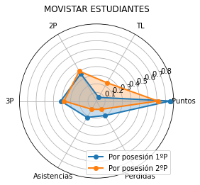

```python
angles2 = np.linspace(0, 2 * np.pi, 6, endpoint=False)
angles2=np.concatenate((angles2, [angles2[0]]))

locvalues3P1 = [locptanotados_equipo1P/locposesiones_equipo1P,loctlintentados_equipo1P/locposesiones_equipo1P,loct2intentados_equipo1P/locposesiones_equipo1P,loct3intentados_equipo1P/locposesiones_equipo1P,locassist_equipo1P/locposesiones_equipo1P,locperdidas_equipo1P/locposesiones_equipo1P]
locvalues3P1=np.concatenate((locvalues3P1, [locvalues3P1[0]]))
locvalues3P2 = [locptanotados_equipo2P/locposesiones_equipo2P,loctlintentados_equipo2P/locposesiones_equipo2P,loct2intentados_equipo2P/locposesiones_equipo2P,loct3intentados_equipo2P/locposesiones_equipo2P,locassist_equipo2P/locposesiones_equipo2P,locperdidas_equipo2P/locposesiones_equipo2P]
locvalues3P2=np.concatenate((locvalues3P2, [locvalues3P2[0]]))
plt.polar(angles2, locvalues3P1, 'o-', linewidth=2,label='Por posesión 1ºP')
plt.fill(angles2, locvalues3P1, alpha=0.25)
plt.polar(angles2, locvalues3P2, 'o-', linewidth=2,label='Por posesión 2ºP')
plt.fill(angles2, locvalues3P2, alpha=0.25)

plt.legend(loc='lower right')
plt.title(campos['tm']['1']['name'])
labels=['Puntos','TL', '2P', '3P','Asistencias','Perdidas']
plt.thetagrids(angles2 * 180 / np.pi, labels)
plt.show()
```

Conclusiones muy similares al punto anterior:

```
 - Menos asistencias por posesión lo que conlleva a menos tiros fáciles y por tanto menos puntos por posesión.

 - Proporción de tiros lanzados muy parecida excepto en el tiro libre, donde en la primera parte apenas se lanzan.
```

**CONCLUSIONES OFENSIVAS**

Exceso de confianza en **Edwin Jackson** ante el mal partido que estaba realizando. Haberle liberado del peso en ataque ante sus malos porcentajes le podría haber ayudado a ir entrando en partido.

El jugador que más daño ha hecho al Barsa en ambas partes ha sido **Victor Arteaga**. Quizá habría sido mejor opción buscarle más al final del partido.

Endurecimiento del partido en la segunda mitad por parte del Barsa. Esto provoca un colapso en el ataque local que no consigue encontrar tiros liberados como en la primera parte. Se traduce en una disminución en el **nº de asistencias y peores porcentajes.**

**CONCLUSIONES FINALES**

Se ha tratado de analizar este partido unicamente con los datos obtenidos de el mismo. Es cierto que los datos de un único partido no son suficientes para analizar tendencias o dinámicas de juego que favorezcan más a un equipo, para los que sería necesario analizar más partidos. Aún así, se puede extrer muchisima información de un partido hasta el punto de poder intuir cómo ha transcurrido el partido sin haberlo visto. Considero que esta información junto a la visualización del partido y las sensaciones del mismo forman la mezcla perfecta para analizar lo ocurrido en un partido y detectar los puntos fuertes y débiles de un equipo.